# Prediccion2_LSTM

## Predicción sobre los precios de las acciones de Google

**Autor: Luis Fernando Apáez Álvarez**

#### Índice

Descripción

Preprocesamiento

Redes neuronales (LSTM)

Hiperparámetros

### Descripción

En la *notebook* anterior implementamos un modelo predictivo de regresión lineal múltiple y un modelo de red neuronal MLP para predecir el precio de apertura de las acciones de Google del día siguiente. Lo que haremos ahora será implementar un modelo de red neuronal LSTM.

De tal manera, comenzamos por realizar las importaciones necesarias y la carga de los datos

```python
import yfinance as yf
import matplotlib.pyplot as plt
import seaborn as sns
import pandas as pd
import numpy as np
plt.style.use('seaborn')

# Instanciamos y configuramos la clave de google
goog = yf.Ticker('goog')

# Obtenemos la informacion
data = goog.history(interval='1d', start='2016-01-01', end='2022-10-01')
data = data.reset_index()
# Damos un vistazo
data.head()
```

|  | Date | Open | High | Low | Close | Volume | Dividends | Stock Splits |
| --- | --- | --- | --- | --- | --- | --- | --- | --- |
| 0 | 2016-01-04 | 37.150002 | 37.202999 | 36.562901 | 37.091999 | 65456000 | 0 | 0.0 |
| 1 | 2016-01-05 | 37.322498 | 37.599998 | 36.931999 | 37.129002 | 39014000 | 0 | 0.0 |
| 2 | 2016-01-06 | 36.500000 | 37.359001 | 36.445999 | 37.181000 | 38940000 | 0 | 0.0 |
| 3 | 2016-01-07 | 36.515499 | 36.924999 | 35.952999 | 36.319500 | 59274000 | 0 | 0.0 |
| 4 | 2016-01-08 | 36.572498 | 36.661499 | 35.650002 | 35.723499 | 49018000 | 0 | 0.0 |

```python
# EL dataset final sera
data = data.drop(["Volume", "Dividends", "Stock Splits"], axis=1)
display(data.head())
display(data.tail())
```

|  | Date | Open | High | Low | Close |
| --- | --- | --- | --- | --- | --- |
| 0 | 2016-01-04 | 37.150002 | 37.202999 | 36.562901 | 37.091999 |
| 1 | 2016-01-05 | 37.322498 | 37.599998 | 36.931999 | 37.129002 |
| 2 | 2016-01-06 | 36.500000 | 37.359001 | 36.445999 | 37.181000 |
| 3 | 2016-01-07 | 36.515499 | 36.924999 | 35.952999 | 36.319500 |
| 4 | 2016-01-08 | 36.572498 | 36.661499 | 35.650002 | 35.723499 |

|  | Date | Open | High | Low | Close |
| --- | --- | --- | --- | --- | --- |
| 1694 | 2022-09-26 | 98.610001 | 100.440002 | 98.379997 | 98.809998 |
| 1695 | 2022-09-27 | 99.910004 | 100.459999 | 97.339996 | 98.089996 |
| 1696 | 2022-09-28 | 98.019997 | 101.400002 | 97.800003 | 100.739998 |
| 1697 | 2022-09-29 | 99.300003 | 99.300003 | 96.519997 | 98.089996 |
| 1698 | 2022-09-30 | 97.730003 | 99.494003 | 96.029999 | 96.150002 |

### Preprocesamiento

Debido a que en los precios de apertura podemos encontrar ciertas diferencias, en algunos casos puede ser que dicha diferencia sea grande. Por ejemplo

```python
# Precio de apertura de la primera fila
print(data.iloc[0][1])
# Precio de apertura de la ultima fila
print(data.iloc[data.shape[0]-1][1])
```

```
37.150001525878906
97.7300033569336
```

vemos que el primer precio dista mucho del último precio, lo cual puede hacer que en la red neuronal se le de menos peso o importancia al primer valor. Lo que haremos entonces será normalizar los datos escalándolos al intervalo $(0,1)$ para disminuir ese tipo de diferencias.

```python
# Importacion necesaria
from sklearn.preprocessing import MinMaxScaler

# Instanciamos y configuramos el escalador.
sc = MinMaxScaler(feature_range = (0, 1))

# Preconjunto de entrenamiento:
training_set = data.loc[:, ['Open', 'High', 'Low', 'Close']].values

# Realizamos el escalado de los datos
training_set_escaled = sc.fit_transform(training_set)
```

Una vez escalados los datos, crearemos los conjunto de entrenamiento, donde para cada dato estaremos retrocediendo 60 días en el pasado. Así, las primeras 60 filas de las columnas `Open, Close, Low, High` corresponden a la información asociada para el valor de la variable objetivo `y` de la columna `Open` de la fila 61

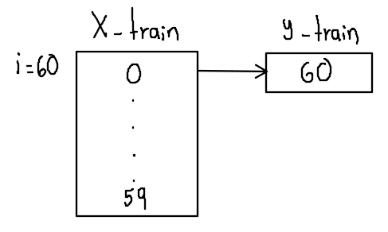

Y así sucesivamente. De tal manera escribimos

```python
# Definicion del conjunto de entrenamiento
X_train = []
y_train = []

for i in range(60, data.shape[0]):
    # Utilizamos la informacion de las columnas Open, Close, Low, High
    # de los 60 dias anteriores a cada fila
    X_train.append(training_set_escaled[i-60:i, 0:4])

    # Valor de la columna Open para la fila i
    y_train.append(training_set_escaled[i, 0])

# Convertimos las listas anteriores en arrays
X_train = np.array(X_train)
y_train = np.array(y_train)
```

Notemos que

```python
data.loc[:, ['Open', 'High', 'Low', 'Close']].tail()
```

|  | Open | High | Low | Close |
| --- | --- | --- | --- | --- |
| 1694 | 98.610001 | 100.440002 | 98.379997 | 98.809998 |
| 1695 | 99.910004 | 100.459999 | 97.339996 | 98.089996 |
| 1696 | 98.019997 | 101.400002 | 97.800003 | 100.739998 |
| 1697 | 99.300003 | 99.300003 | 96.519997 | 98.089996 |
| 1698 | 97.730003 | 99.494003 | 96.029999 | 96.150002 |

```python
# Notamos que para el ultimo array del conjunto de entrenamiento, el ultimo valor
# en la columna de Open es de 99.30, que corresponde al 29 de septiembre
X_train[-1][50:]
```

```
array([[102.97000122, 104.02999878, 101.85500336, 103.62999725],
       [102.54000092, 104.01999664, 102.37000275, 103.84999847],
       [102.87999725, 103.16999817, 101.12000275, 101.83000183],
       [102.23999786, 103.48999786,  99.98999786, 100.01000214],
       [ 99.44999695, 101.68000031,  99.41000366, 100.56999969],
       [100.05999756, 100.11000061,  98.01000214,  99.16999817],
       [ 98.61000061, 100.44000244,  98.37999725,  98.80999756],
       [ 99.91000366, 100.45999908,  97.33999634,  98.08999634],
       [ 98.01999664, 101.40000153,  97.80000305, 100.73999786],
       [ 99.30000305,  99.30000305,  96.51999664,  98.08999634]])
```

```python
# El valor de la "y" asociado al array anterior es el siguiente, el cual corresponde
# al valor de Open para el 30 de septiembre
y_train[-1]
```

```
97.7300033569336
```

Continuando

```python
print('Forma del array x_train: ', X_train.shape)
```

```
Forma del array x_train:  (1639, 60, 4)
```

Esto es, en el conjunto de entrenamiento tenemos 1639 matrices de la forma

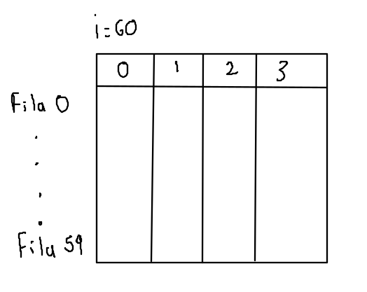

donde la `i` va de 60 a 1698

```python
data.shape[0] - 60
```

```
1639
```

## Redes neuronales LSTM

Procedemos a definir la arquitectura de la red neuronal y a realizar el respectivo entrenamiento de la misma

```python
# Importaciones necesarias
from keras.models import Sequential
from keras.layers import Dense, LSTM, Dropout
from keras.callbacks import ModelCheckpoint

# Arquitectura de la red:

# Guardaremos el mejor modelo
path = 'Prediccion2.hdf5'
c = ModelCheckpoint(filepath = path, monitor = "loss", save_best_only = True,
                    save_freq="epoch")
callbacks = [c]

# 4 capas LSTM con 60 neuronas cada una
model = Sequential()
model.add(LSTM(units=60, return_sequences=True, input_shape=(X_train.shape[1],
                                                             X_train.shape[2])))
# Porcentaje de neuronas a eliminar (evita el sobreajuste).
# Return_sequence: retroalimentacion de la red
model.add(Dropout(rate=0.2))
model.add(LSTM(units=60, return_sequences=True))
model.add(Dropout(rate=0.2))
model.add(LSTM(units=60, return_sequences=True))
model.add(Dropout(rate=0.2))
model.add(LSTM(units=60, return_sequences=False))
model.add(Dropout(rate=0.2))
model.add(Dense(units=1))

# Compilacion del modelo
model.compile(optimizer='adam', loss='mean_squared_error')

# Entrenamiento
model.fit(X_train, y_train, epochs=100, batch_size=32, callbacks=callbacks,
          verbose=False)
```

```
<keras.callbacks.History at 0x1c5afd356d0>
```

```python
from keras.models import load_model

# Cargamos el mejor modelo
modelo_result = load_model('Prediccion2.hdf5')

# Evaluamos el modelo sobre el conjunto de entrenamiento
modelo_result.evaluate(X_train, y_train)
```

```
0.00027102528838440776
```

Veamos el rendimiento de la red sobre el conjunto de entrenamiento

```python
# Realizamos la prediccion sobre el conjunto de entrenamiento
y_pred = modelo_result.predict(X_train)

def inverse_transf(y):
    # auxiliar para regresar la transformacion del escalado. Lo cual es necesario pues
    # el escalado se ajusto sobre los datos de las 4 columnas. Como "y"
    # solo tiene una columna, lo que haremos a continuacion sera agregar 3 columnas
    # de ceros
    extends = np.zeros((len(y), 4))
    extends[:, 0] = y[:, 0]

    # Regresamos a la escala original y solo consideramos la columna para
    # y_pred
    y_transform = sc.inverse_transform(extends)[:, 0]
    y_transform = y_transform.reshape(-1, 1)
    return y_transform


df_aux_0 = pd.DataFrame(inverse_transf(y_train.reshape(-1,1))).rename(columns={0: "y_train"})
df_aux_0["y_pred"] = inverse_transf(y_pred)
df_aux_0
```

|  | y_train | y_pred |
| --- | --- | --- |
| 0 | 37.462502 | 35.836693 |
| 1 | 36.930000 | 36.068410 |
| 2 | 37.502998 | 36.240158 |
| 3 | 36.900002 | 36.323433 |
| 4 | 36.788502 | 36.250866 |
| ... | ... | ... |
| 1634 | 98.610001 | 100.766979 |
| 1635 | 99.910004 | 99.997340 |
| 1636 | 98.019997 | 99.546553 |
| 1637 | 99.300003 | 99.933519 |
| 1638 | 97.730003 | 99.711790 |

1639 rows × 2 columns

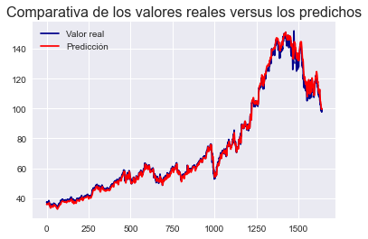

```python
# Graficamente
plt.plot(np.arange(0, len(df_aux_0)),
         df_aux_0["y_train"],
         color='darkblue', label='Valor real')
plt.plot(np.arange(0, len(df_aux_0)),
         df_aux_0["y_pred"],
         color='red', label='Predicción')
plt.title("Comparativa de los valores reales versus los predichos", size=16)
plt.legend()
plt.show()
```

El modelo es muy bueno sobre el conjunto de entrenamiento.

Construiremos ahora el conjunto de pruebas, donde utilizaremos los datos (columna `Open`) del mes de octubre del 2022 (los cuales no fueron considerados en el conjunto de entrenamiento). Para ello

```python
# Consideraremos hasta el 28 de octubre
dataset_test = goog.history(interval='1d', start='2016-10-01', end='2022-10-31')
dataset_test.tail()
```

| Date | Open | High | Low | Close | Volume | Dividends | Stock Splits |
| --- | --- | --- | --- | --- | --- | --- | --- |
| 2022-10-24 | 102.089996 | 103.099998 | 100.300003 | 102.970001 | 24680800 | 0 | 0.0 |
| 2022-10-25 | 103.300003 | 105.099998 | 103.019997 | 104.930000 | 29910200 | 0 | 0.0 |
| 2022-10-26 | 96.760002 | 98.540001 | 94.570000 | 94.820000 | 71504300 | 0 | 0.0 |
| 2022-10-27 | 94.309998 | 95.169998 | 91.900002 | 92.599998 | 54036500 | 0 | 0.0 |
| 2022-10-28 | 92.529999 | 96.860001 | 92.322998 | 96.580002 | 35696900 | 0 | 0.0 |

```python
# Numero de dias a considerar de octubre (dias que no ha visto la red neuronal)
len(goog.history(interval='1d', start='2022-10-01', end='2022-10-31'))
```

```
20
```

Después, para cada uno de los valores anteriores (días de octubre), miraremos 60 días al pasado:

```python
dataset_test = dataset_test[["Open", "High", "Low", "Close"]]

# Consideramos los 60 dias anteriores del primer dia de octubre
# (el dataset resultante tendra solo 80 filas: 20 dias de octubre
# mas los 60 de mirar al pasado)
aux = dataset_test.iloc[len(dataset_test) - 20 - 60:, 0:4].values
# Transformamos
aux = sc.transform(aux)

# Definicion del conjunto de prueba
X_test = []
for i in range(60, len(aux) + 1):
    X_test.append(aux[i-60:i, 0:4])

X_test = np.array(X_test)
```

En este caso sí consideramos toda la última información del conjunto de datos `dataset_test`

```python
dataset_test.tail()
```

| Date | Open | High | Low | Close |
| --- | --- | --- | --- | --- |
| 2022-10-24 | 102.089996 | 103.099998 | 100.300003 | 102.970001 |
| 2022-10-25 | 103.300003 | 105.099998 | 103.019997 | 104.930000 |
| 2022-10-26 | 96.760002 | 98.540001 | 94.570000 | 94.820000 |
| 2022-10-27 | 94.309998 | 95.169998 | 91.900002 | 92.599998 |
| 2022-10-28 | 92.529999 | 96.860001 | 92.322998 | 96.580002 |

```python
X_test[-1][50:]
```

```
array([[ 99.51999664, 101.76999664,  99.51000214, 100.77999878],
       [103.94000244, 104.22000122, 100.65000153, 101.38999939],
       [100.69999695, 101.65899658,  99.63500214, 100.29000092],
       [100.81999969, 103.        ,  99.97000122, 100.52999878],
       [ 98.45999908, 101.62000275,  98.23000336, 101.48000336],
       [102.08999634, 103.09999847, 100.30000305, 102.97000122],
       [103.30000305, 105.09999847, 103.01999664, 104.93000031],
       [ 96.76000214,  98.54000092,  94.56999969,  94.81999969],
       [ 94.30999756,  95.16999817,  91.90000153,  92.59999847],
       [ 92.52999878,  96.86000061,  92.32299805,  96.58000183]])
```

Continuando

```python
print(X_test.shape)
```

```
(21, 60, 4)
```

tenemos que cada una de las 21 matrices será ocupada para predecir el precio de apertura del día siguiente. Por ejemplo, la última matriz (la cual considera el precio de apertura hasta el 28 de octubre) será utilizada para predecir el precio del 31 de octubre del 2022.

Definiremos ahora un dataframe con los valores reales de los precios de apertura de octubre

```python
df_aux = pd.DataFrame(goog.history(interval='1d', start='2022-10-01',
                                   end='2022-11-01')["Open"])
print(df_aux.shape[0])
display(df_aux)
```

```
21
```

| Date | Open |
| --- | --- |
| 2022-10-03 | 97.220001 |
| 2022-10-04 | 101.040001 |
| 2022-10-05 | 100.690002 |
| 2022-10-06 | 101.500000 |
| 2022-10-07 | 100.650002 |
| 2022-10-10 | 99.849998 |
| 2022-10-11 | 98.250000 |
| 2022-10-12 | 98.269997 |
| 2022-10-13 | 95.930000 |
| 2022-10-14 | 100.625000 |
| 2022-10-17 | 99.519997 |
| 2022-10-18 | 103.940002 |
| 2022-10-19 | 100.699997 |
| 2022-10-20 | 100.820000 |
| 2022-10-21 | 98.459999 |
| 2022-10-24 | 102.089996 |
| 2022-10-25 | 103.300003 |
| 2022-10-26 | 96.760002 |
| 2022-10-27 | 94.309998 |
| 2022-10-28 | 92.529999 |
| 2022-10-31 | 95.779999 |

```python
# Realizamos las predicciones
precio_pred = modelo_result.predict(X_test)
precio_pred.shape
```

```
(21, 1)
```

Continuando

```python
# Regresamos a la escala original
precio_pred = inverse_transf(precio_pred)
precio_pred
```

```
array([[ 98.70905442],
       [ 98.54982643],
       [100.58131265],
       [102.43338227],
       [103.43642188],
       [102.56539554],
       [100.7924209 ],
       [ 99.40647571],
       [ 98.9956634 ],
       [ 99.19551575],
       [ 99.4622327 ],
       [100.41267884],
       [101.95780259],
       [102.17787179],
       [101.90984142],
       [101.47022556],
       [102.04885256],
       [103.88308503],
       [101.52212701],
       [ 96.97933099],
       [ 94.46993483]])
```

```python
precio_pred.shape
```

```
(21, 1)
```

Compararemos las predicciones con los valores reales

```python
# Agregamos una columna nueva
df_aux['Open pred'] = precio_pred

# Calculamos las diferencias entre los precios reales y las predicciones
df_aux['Diff'] = df_aux['Open'] - df_aux['Open pred']

# Calculamos el porcentaje de error
df_aux['error'] = (abs(df_aux['Diff']) * 100) / df_aux['Open']
df_aux
```

| Date | Open | Open pred | Diff | error |
| --- | --- | --- | --- | --- |
| 2022-10-03 | 97.220001 | 98.709054 | -1.489053 | 1.531633 |
| 2022-10-04 | 101.040001 | 98.549826 | 2.490174 | 2.464543 |
| 2022-10-05 | 100.690002 | 100.581313 | 0.108690 | 0.107945 |
| 2022-10-06 | 101.500000 | 102.433382 | -0.933382 | 0.919588 |
| 2022-10-07 | 100.650002 | 103.436422 | -2.786420 | 2.768426 |
| 2022-10-10 | 99.849998 | 102.565396 | -2.715397 | 2.719476 |
| 2022-10-11 | 98.250000 | 100.792421 | -2.542421 | 2.587706 |
| 2022-10-12 | 98.269997 | 99.406476 | -1.136479 | 1.156486 |
| 2022-10-13 | 95.930000 | 98.995663 | -3.065663 | 3.195729 |
| 2022-10-14 | 100.625000 | 99.195516 | 1.429484 | 1.420605 |
| 2022-10-17 | 99.519997 | 99.462233 | 0.057764 | 0.058043 |
| 2022-10-18 | 103.940002 | 100.412679 | 3.527324 | 3.393615 |
| 2022-10-19 | 100.699997 | 101.957803 | -1.257806 | 1.249062 |
| 2022-10-20 | 100.820000 | 102.177872 | -1.357872 | 1.346828 |
| 2022-10-21 | 98.459999 | 101.909841 | -3.449842 | 3.503801 |
| 2022-10-24 | 102.089996 | 101.470226 | 0.619771 | 0.607083 |
| 2022-10-25 | 103.300003 | 102.048853 | 1.251150 | 1.211181 |
| 2022-10-26 | 96.760002 | 103.883085 | -7.123083 | 7.361599 |
| 2022-10-27 | 94.309998 | 101.522127 | -7.212129 | 7.647259 |
| 2022-10-28 | 92.529999 | 96.979331 | -4.449332 | 4.808529 |
| 2022-10-31 | 95.779999 | 94.469935 | 1.310064 | 1.367784 |

Tenemos que la red ha predicho un precio de apertura para el 31 de octubre de 94.46, con un error porcentual del 1.36%. En general:

```python
df_aux.describe()["error"]
```

```
count    21.000000
mean      2.448901
std       2.065607
min       0.058043
25%       1.211181
50%       1.531633
75%       3.195729
max       7.647259
Name: error, dtype: float64
```

El error promedio fue del 2.44%, el 75% de los errores fueron menores o iguales al 3.19% y el error máximo fue de 7.64%.

Gráficamente

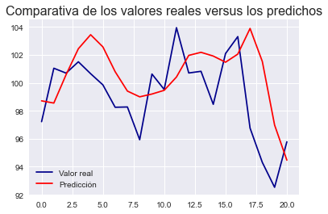

```python
plt.plot(np.arange(0, len(df_aux)),
         df_aux["Open"],
         color='darkblue', label='Valor real')
plt.plot(np.arange(0, len(df_aux)),
         df_aux["Open pred"],
         color='red', label='Predicción')
plt.title("Comparativa de los valores reales versus los predichos", size=16)
plt.legend()
plt.show()
```

lo que, en resumen, nos dice que el modelo obtenido hasta ahora es bueno, pero no mejor que los dos modelos que habíamos visto antes.

Veamos el ajuste de la tendencia producto de la red neuronal recurrente:

```python
# Cambiamos los nombres de las columnas
df_aux_0 = df_aux_0.rename(columns={"y_train": "Open", "y_pred":"Open pred"})
# Cambiamos el indice
df_aux_0.index = data.iloc[60:, 0]
# Juntamos los dataframes comparativos de los datos de entrenamiento
# y de prueba
df_tend = pd.concat([df_aux_0, df_aux[["Open", "Open pred"]]])
df_tend
```

| Date | Open | Open pred |
| --- | --- | --- |
| 2016-03-31 | 37.462502 | 35.836693 |
| 2016-04-01 | 36.930000 | 36.068410 |
| 2016-04-04 | 37.502998 | 36.240158 |
| 2016-04-05 | 36.900002 | 36.323433 |
| 2016-04-06 | 36.788502 | 36.250866 |
| ... | ... | ... |
| 2022-10-25 | 103.300003 | 102.048853 |
| 2022-10-26 | 96.760002 | 103.883085 |
| 2022-10-27 | 94.309998 | 101.522127 |
| 2022-10-28 | 92.529999 | 96.979331 |
| 2022-10-31 | 95.779999 | 94.469935 |

1660 rows × 2 columns

```python
print(len(df_aux_0))
print(len(df_aux))
```

```
1639
21
```

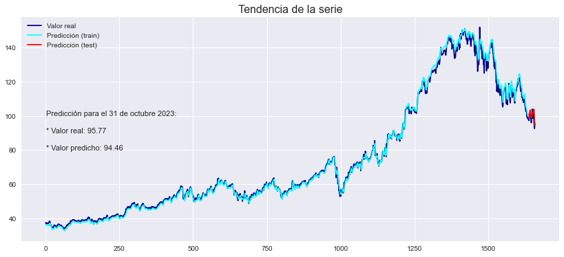

```python
# Graficamos
plt.figure(figsize=(14,6))

plt.plot(np.arange(0, len(df_tend)),
         df_tend["Open"],
         color='darkblue', label='Valor real')
plt.plot(np.arange(0, len(df_aux_0)),
         df_tend["Open pred"][0:len(df_aux_0)],
         color='#11FFFC', label='Predicción (train)')
plt.plot(np.arange(len(df_aux_0), len(df_tend)),
         df_tend["Open pred"][len(df_aux_0):],
         color='red', label='Predicción (test)')
plt.title("Tendencia de la serie", size=16)
plt.text(1, 100, "Predicción para el 31 de octubre 2023:", size=11)
plt.text(1, 90, "* Valor real: 95.77", size=11)
plt.text(1, 80, "* Valor predicho: 94.46", size=11)
plt.legend()
plt.show()
```

Notamos que la red neuronal ajusta bastante bien la tendencia de la serie de tiempo.

## Hiperparámetros

Utilizaremos la siguiente función para buscar un mejor modelo

```python
def neuronal_LSTM(n, opt, loss, epocas, k):
    """Función para buscar un mejor modelo de la red neuronal LSTM.
    * n: número de neuronas para cada una de las capas;
    * opt: optimizador;
    * loss: función de pérdida;
    * epocas: número de épocas para el entrenamiento;
    * k: tamaño del lote.
    La función retorna el modelo entrenado de la red y un
    dataframe con los valores reales y predichos para el mes de octubre
    (conjunto de prueba)."""

    # 4 capas LSTM con n neuronas cada una
    model = Sequential()
    model.add(LSTM(units=n, return_sequences=True, input_shape=(X_train.shape[1],
                                                                X_train.shape[2])))
    # Porcentaje de neuronas a eliminar (evita el sobreajuste).
    # Return_sequence: retroalimentacion de la red
    model.add(Dropout(rate=0.2))
    model.add(LSTM(units=n, return_sequences=True))
    model.add(Dropout(rate=0.2))
    model.add(LSTM(units=n, return_sequences=True))
    model.add(Dropout(rate=0.2))
    model.add(LSTM(units=n, return_sequences=False))
    model.add(Dropout(rate=0.2))
    model.add(Dense(units=1))

    # Compilacion del modelo
    model.compile(optimizer=opt, loss=loss)
    # Entrenamiento
    model.fit(X_train, y_train, epochs=epocas, batch_size=k, verbose=False)

    # Dataframe auxiliar con la informacion de las predicciones hechas en el
    # entrenamiento
    y_pred_train = model.predict(X_train)
    df_aux_0 = pd.DataFrame(inverse_transf(y_train.reshape(-1,1)))
    df_aux_0 = df_aux_0.rename(columns={0: "y_train"})
    df_aux_0["y_pred"] = inverse_transf(y_pred_train)
    df_aux_0["Diff"] = abs(df_aux_0["y_train"] - df_aux_0["y_pred"])
    df_aux_0["Error (%)"] = (df_aux_0["Diff"] * 100) / df_aux_0["y_train"]

    # Retornaremos el error porcentual promedio referente al entrenamiento
    error_promedio_train = df_aux_0["Error (%)"].mean()

    # Dataframe auxilar con los valores reales asociados al conjunto de prueba
    df_aux = pd.DataFrame(goog.history(interval='1d', start='2022-10-01',
                                       end='2022-11-01')["Open"])
    # Realizamos la prediccion sobre el conjunto de prueba
    precio_pred = model.predict(X_test)
    # Regresamos a la escala original
    precio_pred = inverse_transf(precio_pred)
    # Agregamos una columna nueva
    df_aux['Open pred'] = precio_pred
    # Calculamos las diferencias entre los precios reales y las predicciones
    df_aux['Diff'] = df_aux['Open'] - df_aux['Open pred']
    # Calculamos el porcentaje de error
    df_aux['error'] = (abs(df_aux['Diff']) * 100) / df_aux['Open']
    # Retornaremos el dataframe anterior

    # Obtenemos algunas estadisticos de dicho dataframe sobre la columna error
    print("Porcentajes en la prueba")
    display(df_aux.describe().loc[["mean", "min", "max", "75%"], "error"])
    print("-" * 40)
    # Arrojamos otro mensaje sobre el entrenamiento
    print(f'Error porcentual promedio en el entrenamiento: {error_promedio_train}')

    # Graficamos
    plt.plot(np.arange(0, len(df_aux)),
             df_aux["Open"],
             color='darkblue', label='Valor real')
    plt.plot(np.arange(0, len(df_aux)),
             df_aux["Open pred"],
             color='red', label='Predicción')
    plt.title("Comparativa de los valores reales versus los predichos", size=16)
    plt.legend()
    plt.show()
    return df_aux, model
```

```
Porcentajes en la prueba
```

```
mean     4.369903
min      0.428928
max     12.442252
75%      5.773003
Name: error, dtype: float64
```

```
----------------------------------------
Error porcentual promedio en el entrenamiento: 2.445104825546982
```

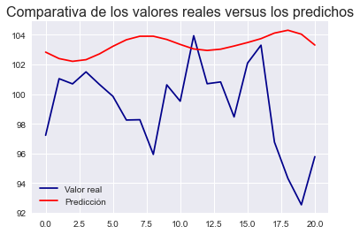

```python
df_aux_1, modelo1 = neuronal_LSTM(60, "adam", "mean_squared_error", 40, 32)
```

```
Porcentajes en la prueba
```

```
mean     6.046524
min      0.184903
max     12.685512
75%      7.786923
Name: error, dtype: float64
```

```
----------------------------------------
Error porcentual promedio en el entrenamiento: 3.9093027306230077
```

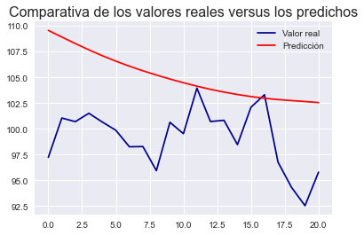

```python
df_aux_2, modelo2 = neuronal_LSTM(60, "sgd", "mean_squared_error", 40, 32)
```

```
Porcentajes en la prueba
```

```
mean    2.675408
min     0.370336
max     8.995869
75%     3.790384
Name: error, dtype: float64
```

```
----------------------------------------
Error porcentual promedio en el entrenamiento: 2.4834253572911944
```

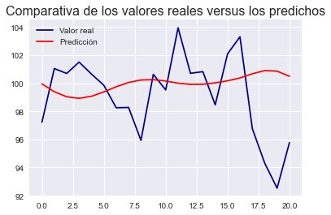

```python
df_aux_3, modelo3 = neuronal_LSTM(60, "adam", "mean_squared_error", 40, 50)
```

```
Porcentajes en la prueba
```

```
mean     3.522202
min      0.262229
max     11.385504
75%      4.886447
Name: error, dtype: float64
```

```
----------------------------------------
Error porcentual promedio en el entrenamiento: 2.4652078472091907
```

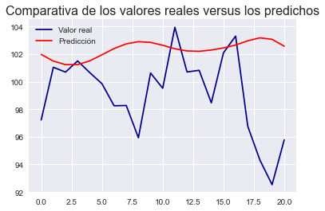

```python
df_aux_4, modelo4 = neuronal_LSTM(75, "adam", "mean_squared_error", 40, 50)
```

```
Porcentajes en la prueba
```

```
mean    2.271454
min     0.152122
max     5.516029
75%     3.683811
Name: error, dtype: float64
```

```
----------------------------------------
Error porcentual promedio en el entrenamiento: 1.675446625038659
```

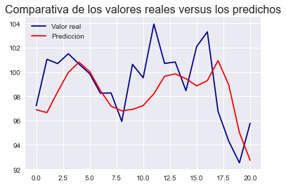

```python
df_aux_5, modelo5 = neuronal_LSTM(60, "adam", "mean_squared_error", 140, 50)
```

```
Porcentajes en la prueba
```

```
mean    2.287174
min     0.204370
max     9.305963
75%     2.994370
Name: error, dtype: float64
```

```
----------------------------------------
Error porcentual promedio en el entrenamiento: 1.224698341112644
```

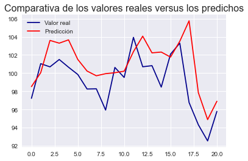

```python
df_aux_6, modelo6 = neuronal_LSTM(60, "adam", "mean_squared_error", 240, 50)
```

```
Porcentajes en la prueba
```

```
mean     5.325093
min      0.267265
max     10.370986
75%      6.788549
Name: error, dtype: float64
```

```
----------------------------------------
Error porcentual promedio en el entrenamiento: 12.531181120847608
```

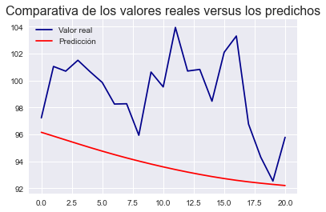

```python
df_aux_7, modelo7 = neuronal_LSTM(60, "Adadelta", "mean_squared_error", 40, 50)
```

```
Porcentajes en la prueba
```

```
mean    2.753463
min     0.228584
max     7.211932
75%     4.239854
Name: error, dtype: float64
```

```
----------------------------------------
Error porcentual promedio en el entrenamiento: 2.6419638870066526
```

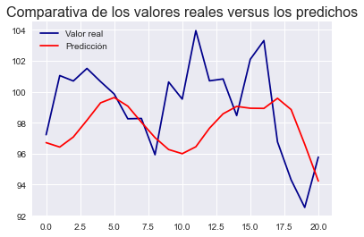

```python
df_aux_8, modelo8 = neuronal_LSTM(60, "adam", "mean_squared_error", 140, 70)
```

```
Porcentajes en la prueba
```

```
mean    2.703016
min     0.114629
max     6.267275
75%     4.181629
Name: error, dtype: float64
```

```
----------------------------------------
Error porcentual promedio en el entrenamiento: 2.2567188390374913
```

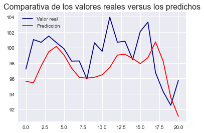

```python
df_aux_9, modelo9 = neuronal_LSTM(50, "adam", "mean_squared_error", 140, 50)
```

[output not shown]

En resumen tenemos:

[output not shown]

```python
# Realizamos la importacion necesaria
from IPython.display import Markdown

# definimos una funcion que ocupara la funcion recien importada
# Markdown()
def printmd(string):
    # Mostramos en salida la cadena de texto ingresada
    # pero en formato Markdown (dentro de Markdown podemos
    # escribir codigo latex)
    display(Markdown(string))

# Imprimimos
printmd('### Estadísticas del modelo 5')
display(df_aux_5.describe()["error"])

print("-" * 31)
printmd('### Estadísticas del primer modelo')
display(df_aux.describe()["error"])
```

Estadísticas del modelo 5

[output not shown]

Estadísticas del primer modelo

```
count    21.000000
mean      2.448901
std       2.065607
min       0.058043
25%       1.211181
50%       1.531633
75%       3.195729
max       7.647259
Name: error, dtype: float64
```

```python
# Realizamos las predicciones
precio_pred5 = modelo5.predict(X_test)
precio_pred5 = inverse_transf(precio_pred5)

# Dataframe con los precios verdaderos de octubre
df_aux5 = pd.DataFrame(goog.history(interval='1d', start='2022-10-01',
                                    end='2022-11-01')["Open"])

# Agregamos una columna nueva
df_aux5['Open pred'] = precio_pred5

# Calculamos las diferencias entre los precios reales y las predicciones
df_aux5['Diff'] = df_aux5['Open'] - df_aux5['Open pred']

# Calculamos el porcentaje de error
df_aux5['error'] = (abs(df_aux5['Diff']) * 100) / df_aux5['Open']
df_aux5.tail()
```

| Date | Open | Open pred | Diff | error |
| --- | --- | --- | --- | --- |
| 2022-10-25 | 103.300003 | 99.287244 | 4.012759 | 3.884569 |
| 2022-10-26 | 96.760002 | 100.931820 | -4.171818 | 4.311511 |
| 2022-10-27 | 94.309998 | 98.941128 | -4.631130 | 4.910540 |
| 2022-10-28 | 92.529999 | 95.007584 | -2.477586 | 2.677603 |
| 2022-10-31 | 95.779999 | 92.732543 | 3.047456 | 3.181725 |

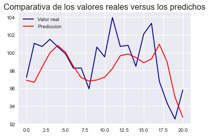

```python
# Graficamos
plt.plot(np.arange(0, len(df_aux5)),
            df_aux5["Open"],
            color='darkblue', label='Valor real')
plt.plot(np.arange(0, len(df_aux5)),
            df_aux5["Open pred"],
            color='red', label='Predicción')
plt.title("Comparativa de los valores reales versus los predichos", size=16)
plt.legend()
plt.show()
```

A pesar de que el modelo es mejor, obtuvimos una predicción con un error mayor para dicho día de interés.

```python
print(f'Predicción con el primer modelo:\nReal={95.77999994}, predicción={94.46}')
print("-" * 35)
print(f'Predicción con el modelo 5:\nReal={95.77999994}, predicción={92.73}')
```

```
Predicción con el primer modelo:
Real=95.77999994, predicción=94.46
-----------------------------------
Predicción con el modelo 5:
Real=95.77999994, predicción=92.73
```

```python
# Error porcentual de la prediccion para la fecha de interes
((95.77999994-92.73) * 100) / 95.77999994
```

```
3.1843808121848203
```